# Machine Learning Course Project

16-Dec-2018

## Get the Data

Using the URLs provided by the prompt, we obtain the training and testing sets, and then store them in local variables. Of note, by peeking at the training data set in Excel, we see some errors of the form: “#DIV/O!”. It is best to take care of these with the data load. The code is commented out where appropriate to avoid redownloading.

```r
library(knitr)
setwd("/Users/fred/Documents/CourseraCourses/dataScienceSpecialization/crs8_practicalMachineLearning/project/")
#train_url <- "https://d396qusza40orc.cloudfront.net/predmachlearn/pml-training.csv"
#download.file(url=train_url, destfile="training.csv")

#test_url <- "https://d396qusza40orc.cloudfront.net/predmachlearn/pml-testing.csv"
#download.file(url=test_url, destfile="testing.csv")

train <- read.csv("training.csv", na.strings=c("NA","#DIV/0!",""))
test <- read.csv("testing.csv", na.strings=c("NA","#DIV/0!",""))

#explore response variable -- classe
str(train$classe)
```

```
##  Factor w/ 5 levels "A","B","C","D",..: 1 1 1 1 1 1 1 1 1 1 ...
```

```r
summary(train$classe)
```

```
##    A    B    C    D    E
## 5580 3797 3422 3216 3607
```

## Model Approach

Since the response variable `classe` is a factor, our model will be some type of classification function. In other words, a classification type model like a tree or random forest might be more appropriate than say a linear regression model, which is better suited for a continuous response. We’ll use cross-validation to help with predictor variable selection as well as model selection. To do so, we’ll subset the training data set into training and testing sets.

```r
library(caret)
set.seed(7531)
inTrain <- createDataPartition(y = train$classe, p = 0.6, list = F)
sub_train <- train[inTrain,]
sub_test <- train[-inTrain,]
dim(sub_train)
```

```
## [1] 11776   160
```

```r
dim(sub_test)
```

```
## [1] 7846  160
```

## Variable Selection

### Removing Zero Covariates

We’ll search through the training subset for the *near zero variables*, i.e. the ones with such little variability that they are not useful in prediction. Of course, we’ll need to do the same in the testing subset.

```r
#scan through training subset for nsv's; assign the column positions to a variable
nsv <- nearZeroVar(sub_train)
head(nsv,10)
```

```
##  [1]  6 14 17 26 51 52 53 54 55 56
```

```r
#do the same for the testing subset and original test
nsv2 <- nearZeroVar(sub_test)
nsv3 <- nearZeroVar(test)

#remove near zero variables by excluding columns
sub_train2 <- sub_train[, -nsv]
sub_test2 <- sub_test[, -nsv2]

#sanity check on data frame dimensions after processing
dim(sub_train2)
```

```
## [1] 11776   130
```

```r
dim(sub_test2)
```

```
## [1] 7846  129
```

### Removing Blank Variables

Now we’ll search through the training subset for variables which contain majority blank (NA) values as these are not very helpful in prediction; let’s use 60% as the threshhold. Again, we do the same to the testing subset. Full disclosure, this code was found from another Coursera user and modified to suit my needs [1].

```r
sub_train3 <- sub_train2
for (i in 1:length(sub_train2)) {
  if (sum(is.na(sub_train2[ , i]))/nrow(sub_train2) >= .6) {
    for (j in 1:length(sub_train3)) {
      if (length(grep(names(sub_train2[i]), names(sub_train3)[j])) == 1) {
        sub_train3 <- sub_train3[ , -j]
      }
    }
  }
}

#check if removal changed columns
dim(sub_train3)
```

```
## [1] 11776    59
```

```r
#changing all columns to numeric
sub_train3[,c(1,3,4,6:58)] <- sapply(sub_train3[,c(1,3,4,6:58)], as.numeric)
```

```r
#same NA removal operation on testing subset
sub_test3 <- sub_test2
for (i in 1:length(sub_test2)) {
  if (sum(is.na(sub_test2[ , i]))/nrow(sub_test2) >= .6) {
    for (j in 1:length(sub_test3)) {
      if (length(grep(names(sub_test2[i]), names(sub_test3)[j])) == 1) {
        sub_test3 <- sub_test3[ , -j]
      }
    }
  }
}

dim(sub_test3)
```

```
## [1] 7846   59
```

```r
sub_test3[,c(1,3,4,6:58)] <- sapply(sub_test3[,c(1,3,4,6:58)], as.numeric)
```

As you can see, we’ve reduced the variable space down to 58 (59th is the response). Additionally, this next operation below is due to much trial-and-error. When predicting the random forest, there were issues in data compatibility between training and testing sets. Even with the change to all numeric columns, the factor columns still presented issues due to the different number of levels. I chose to remove the factor columns as they don’t seem to be that important to prediction anyways, along with the other initial columns as they deal with user names and timestamps.

```r
#removing first 5 columns
sub_train3 <- sub_train3[,-c(1:5)]
sub_test3 <- sub_test3[,-c(1:5)]
```

## Decision Tree Model

We train a tree model on our partitioned training set (noted as `sub_train3`). We then use it to predict on the other partition used for testing (noted as `sub_test`). The `rpart` function is used rather than `train` due to processing time.

### Model Build

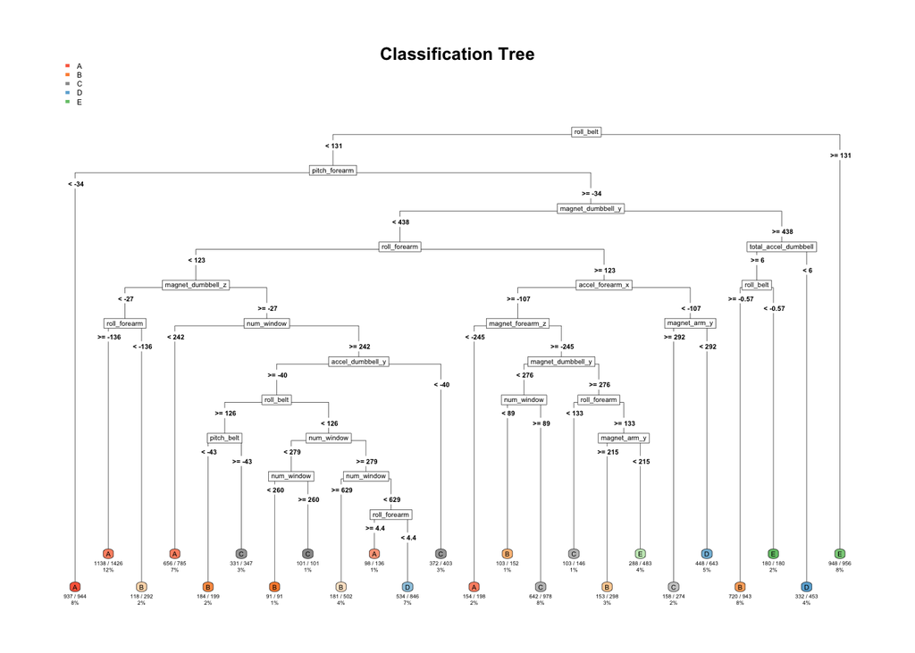

```r
#build the model; rpart is used instead of train
library(rpart)
trainTree <- rpart(classe ~ ., data = sub_train3, method="class")

#plotting tree with rpart.plot method
library(rpart.plot)
rpart.plot(trainTree, main="Classification Tree", extra=102, type = 5, under=T)
```

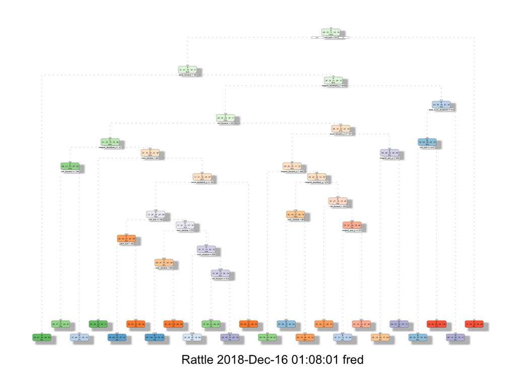

```r
#fancier tree plot
library(rattle)
fancyRpartPlot(trainTree)
```

### Model Prediction

Now we predict new values using the tree on the partitioned testing set.

```r
#predict on testing subset
pred1 <- predict(trainTree, sub_test3, type = "class")
```

### Evaluate Performance

Now we’ll compare the tree model’s performance to the subset used for testing.

```r
confusionMatrix(pred1, sub_test3$classe)
```

```
## Confusion Matrix and Statistics
##
##           Reference
## Prediction    A    B    C    D    E
##          A 1991  211   14   68   59
##          B  164 1010   92  172  170
##          C   33  122 1123  119   77
##          D   33  127  120  860  175
##          E   11   48   19   67  961
##
## Overall Statistics
##
##                Accuracy : 0.7577
##                  95% CI : (0.7481, 0.7672)
##     No Information Rate : 0.2845
##     P-Value [Acc > NIR] : < 2.2e-16
##
##                   Kappa : 0.693
##  Mcnemar's Test P-Value : < 2.2e-16
##
## Statistics by Class:
##
##                      Class: A Class: B Class: C Class: D Class: E
## Sensitivity            0.8920   0.6653   0.8209   0.6687   0.6664
## Specificity            0.9373   0.9055   0.9458   0.9306   0.9774
## Pos Pred Value         0.8498   0.6281   0.7619   0.6540   0.8689
## Neg Pred Value         0.9562   0.9186   0.9616   0.9348   0.9286
## Prevalence             0.2845   0.1935   0.1744   0.1639   0.1838
## Detection Rate         0.2538   0.1287   0.1431   0.1096   0.1225
## Detection Prevalence   0.2986   0.2049   0.1879   0.1676   0.1410
## Balanced Accuracy      0.9147   0.7854   0.8834   0.7997   0.8219
```

Examining the output from above, we see that the tree accuracy is **0.7577**, which means its estimated out-of-sample error is **0.2423**. Thus, we’ll explore another model–random forest–which should improve on accuracy.

## Random Forest Model

The same data sets are used, but this time we’ll use the random forest model, usually a top performing model in many prediction circumstances.

### Model Build

```r
#build the model
library(randomForest)
set.seed(7531)
trainForest <- randomForest(classe ~., data = sub_train3)
```

### Model Prediction

Now we predict new values using the forest on the partitioned testing set.

```r
#predict
pred2 <- predict(trainForest, newdata = sub_test3, type = "class")
```

### Evaluate Performance

Now we’ll compare the forest model’s performance to the subset used for testing.

```r
confusionMatrix(pred2, sub_test3$classe)
```

```
## Confusion Matrix and Statistics
##
##           Reference
## Prediction    A    B    C    D    E
##          A 2232    4    0    0    0
##          B    0 1514    7    0    0
##          C    0    0 1355    6    0
##          D    0    0    6 1278    6
##          E    0    0    0    2 1436
##
## Overall Statistics
##
##                Accuracy : 0.996
##                  95% CI : (0.9944, 0.9973)
##     No Information Rate : 0.2845
##     P-Value [Acc > NIR] : < 2.2e-16
##
##                   Kappa : 0.995
##  Mcnemar's Test P-Value : NA
##
## Statistics by Class:
##
##                      Class: A Class: B Class: C Class: D Class: E
## Sensitivity            1.0000   0.9974   0.9905   0.9938   0.9958
## Specificity            0.9993   0.9989   0.9991   0.9982   0.9997
## Pos Pred Value         0.9982   0.9954   0.9956   0.9907   0.9986
## Neg Pred Value         1.0000   0.9994   0.9980   0.9988   0.9991
## Prevalence             0.2845   0.1935   0.1744   0.1639   0.1838
## Detection Rate         0.2845   0.1930   0.1727   0.1629   0.1830
## Detection Prevalence   0.2850   0.1939   0.1735   0.1644   0.1833
## Balanced Accuracy      0.9996   0.9981   0.9948   0.9960   0.9978
```

As to be expected, the forest performs better than the tree as evidenced by its accuracy of **0.996**, which means its estimated out-of-sample error is **0.004**. Based off this accuracy measure, we’ll choose the random forest to proceed with evaluation on the original test set provided by the course.

## Final Model Application

Below we’ll apply the random forest model to the original test set and attempt to predict on the 20 test cases.

```r
#remove near zero variates in test set
new_test <- test[,-nsv3]

#remove majority NA columns
new_test2 <- new_test
for (i in 1:length(new_test)) {
  if (sum(is.na(new_test[ , i]))/nrow(new_test) >= .6) {
    for (j in 1:length(new_test2)) {
      if (length(grep(names(new_test[i]), names(new_test2)[j])) == 1) {
        new_test2 <- new_test2[ , -j]
      }
    }
  }
}

#same pre-processing steps as before
new_test2[,c(1,3,4,6:58)] <- sapply(new_test2[,c(1,3,4,6:58)], as.numeric)
new_test2 <- new_test2[,-c(1:5)]

#predict on the test set
finalModel <- predict(trainForest, new_test2)
finalModel
```

```
##  1  2  3  4  5  6  7  8  9 10 11 12 13 14 15 16 17 18 19 20
##  B  A  B  A  A  E  D  B  A  A  B  C  B  A  E  E  A  B  B  B
## Levels: A B C D E
```

## References

[1] Anonymous. https://rstudio-pubs-static.s3.amazonaws.com/120618_b9d85bae44c245a38dca5444e4831727.html

[2] Ugolino, W. et al. http://web.archive.org/web/20161224072740/http:/groupware.les.inf.puc-rio.br/har